# Seinna R verkefni

Þorvaldur Tumi Baldursson (ttb3@hi.is)

2023-02-01

# Hluti 1 - Gagnameðhöndlun

## byrjum á að lesa inn gögnin:

```r
hsth <- read.table(
  "https://ahj.hi.is/husnaedisverd_2017_21.csv",
  sep = ";",
  header = TRUE,
  stringsAsFactors = TRUE,
)
```

## veljum síðan þrjú hverfi

- Fossvogur
- breiðholt
- austur kópavog

```r
hverfi <- c(280, 25, 320)
hsth <- dplyr::filter(hsth, matssvaedi %in% hverfi)
```

## athugum gerð breyta

```r
print(str(hsth))
```

```
## 'data.frame':    2130 obs. of  5 variables:
##  $ kaupverd  : int  18000 13500 67000 51500 52800 63800 18000 50000 32000 36000 ...
##  $ teg_eign  : Factor w/ 4 levels "Einbýlishús",..: 2 2 1 2 4 1 2 1 2 1 ...
##  $ byggar    : int  1973 1971 1970 1995 1969 1924 1989 1962 2007 1955 ...
##  $ birtm2    : num  89.5 49.9 197.1 216.4 220.7 ...
##  $ matssvaedi: int  320 320 280 320 280 25 25 320 320 320 ...
## NULL
```

týpur breytanna lýta út fyrir að vera réttar

## búum til fermetra breytu

```r
hsth <- hsth %>% mutate(fermetraverd = kaupverd / birtm2)
```

## tegund eigna

```r
hsth <- hsth %>% mutate(teg_eign_s_i = case_when(
  teg_eign %in% c("Einbýlishús", "Parhús", "Raðhús") ~ "Sérbýli",
  teg_eign %in% c("Íbúðareign") ~ "Íbúð"
))
```

## hverfi

```r
hsth <- hsth %>% transmute(hsth,
  matssvaedi = case_when(
    matssvaedi == 280 ~ "Fossvogur",
    matssvaedi == 25 ~ "Bakkar",
    matssvaedi == 320 ~ "Kópavogur Au."
  )
)
```

## Slembiúrtak úr gagnasafninu af stærð 400

```r
set.seed(27) # setjid uppahalds toluna ykkar her
urtak <- sample_n(hsth, 400)
```

# Hluti 2

## Tafla sem sýnir fjölda eigna í hverfunum þremur eftir gerð eigna (sérbýli eða íbúðir).

```r
knitr::kable(table(urtak$matssvaedi, urtak$teg_eign_s_i), "simple")
```

|  | Íbúð | Sérbýli |
| --- | --- | --- |
| Bakkar | 68 | 6 |
| Fossvogur | 45 | 27 |
| Kópavogur Au. | 211 | 43 |

## Tafla sem sýnir hlutfall sérbýla og íbúða í hverfunum þremur

```r
knitr::kable(round(
  prop.table(
    table(
      urtak$matssvaedi,
      urtak$teg_eign_s_i
    ),
    1
  ),
  3
), "simple")
```

|  | Íbúð | Sérbýli |
| --- | --- | --- |
| Bakkar | 0.919 | 0.081 |
| Fossvogur | 0.625 | 0.375 |
| Kópavogur Au. | 0.831 | 0.169 |

## Kanna með viðeigandi tilgátuprófi hvort samband sé á milli hverfa og gerð eigna (sérbýli og íbúða)

```r
tiltest1 <- prop.test(table(urtak$matssvaedi, urtak$teg_eign_s_i))
tiltest1
```

```
##
##  3-sample test for equality of proportions without continuity correction
##
## data:  table(urtak$matssvaedi, urtak$teg_eign_s_i)
## X-squared = 22.424, df = 2, p-value = 0.00001351
## alternative hypothesis: two.sided
## sample estimates:
##    prop 1    prop 2    prop 3
## 0.9189189 0.6250000 0.8307087
```

```r
tiltest1$expected %>% knitr::kable()
```

[output not shown]

Eins og við sjáum eru forsendur uppfylltar því að þær eru yfir 5. Við höfnum núlltilgátunni því p-gildið er minna en $\alpha$. Gildi prófstærðar er 22.424 og p-gildið 0.000014.

Því ályktum við að samband sé á milli hverfa og gerð eigna.

# Hluti 3

## Kannið með viðeigandi tilgátuprófi hvort munur sé á meðalfermetraverði fasteigna eftir því hvort þær séu sérbýli eða íbúðir

```r
fervik <- aov(fermetraverd ~ teg_eign_s_i, data = urtak)
anova(fervik)
```

```
## Analysis of Variance Table
##
## Response: fermetraverd
##               Df  Sum Sq Mean Sq F value     Pr(>F)
## teg_eign_s_i   1  103200  103200  17.846 0.00002973 ***
## Residuals    398 2301610    5783
## ---
## Signif. codes:  0 '***' 0.001 '**' 0.01 '*' 0.05 '.' 0.1 ' ' 1
```

Við höfnum núlltilgátunni því p-gildið er minna en $\alpha$. Gildi prófstærðar er 17.846 og p-gildið 0.0000297.

Því ályktum við að munur sé á meðalfermetraverði fasteigna eftir því hvort þær séu sérbýli eða íbúðir.

## Búið til nýja breytu, staerd150, sem gefur til kynna hvort eignir séu stærri eða minni en 150 fermetrar

```r
urtak <- mutate(urtak, staerd150 = ifelse(birtm2 > 150.0, "Stærri", "Minni"))
```

## Kannið með viðeigandi tilgátuprófi hvort munur sé á meðfermetraverði fasteigna eftir því hvort þær séu stærri eða minni en 150 fermetrar.

```r
fervik2 <- aov(urtak$fermetraverd ~ urtak$staerd150, data = urtak)
anova(fervik2)
```

```
## Analysis of Variance Table
##
## Response: urtak$fermetraverd
##                  Df  Sum Sq Mean Sq F value    Pr(>F)
## urtak$staerd150   1   81998   81998   14.05 0.0002044 ***
## Residuals       398 2322811    5836
## ---
## Signif. codes:  0 '***' 0.001 '**' 0.01 '*' 0.05 '.' 0.1 ' ' 1
```

Við höfnum núlltilgátunni því p-gildið er minna en $\alpha$.

Gildi prófstærðar er 14.05 og p-gildið 0.0002.

# Hluti 4

## Teiknið viðeigandi mynd af breytunum fermetraverd og matssvaedi.

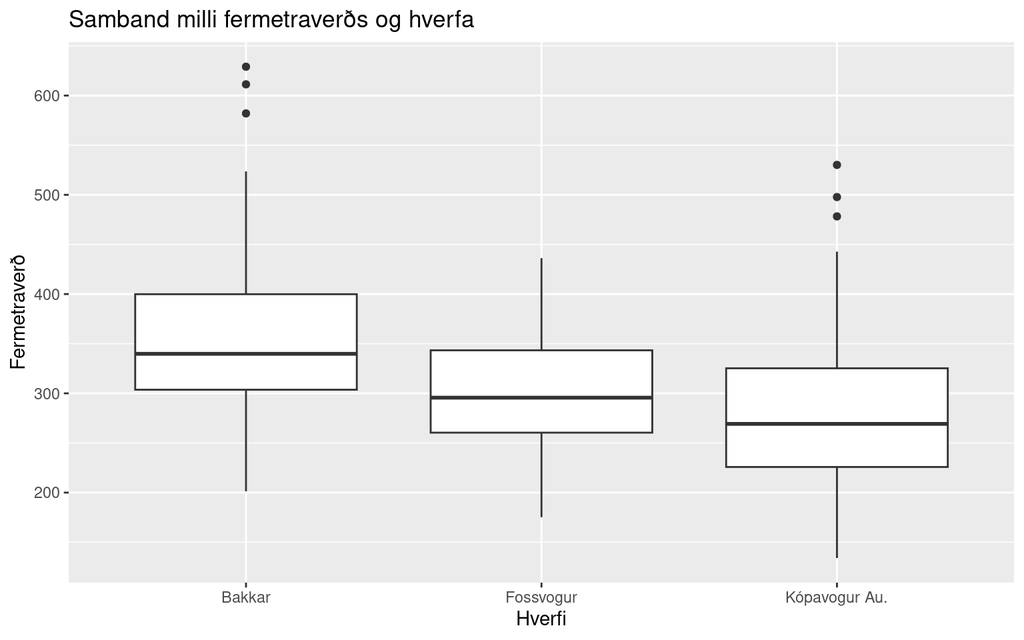

```r
ggplot(
  urtak,
  aes(y = fermetraverd, x = matssvaedi)
) +
  geom_boxplot() +
  xlab("Hverfi") +
  ylab("Fermetraverð") +
  labs(title = "Samband milli fermetraverðs og hverfa")
```

## Kannað með viðeigandi tilgátuprófi hvort munur sé á meðalfermetraverði fasteigna í hverfunum þremur.

```r
fervik3 <- aov(fermetraverd ~ matssvaedi, data = urtak)
anova(fervik3)
```

```
## Analysis of Variance Table
##
## Response: fermetraverd
##             Df  Sum Sq Mean Sq F value                Pr(>F)
## matssvaedi   2  411128  205564  40.934 < 0.00000000000000022 ***
## Residuals  397 1993682    5022
## ---
## Signif. codes:  0 '***' 0.001 '**' 0.01 '*' 0.05 '.' 0.1 ' ' 1
```

Við höfnum núlltilgátunni því p-gildið er minni en $\alpha$. Gildi prófstærðar er 40.934 og p-gildið 0.

Eins og sjá má á myndinni hér fyrir ofan, sem sýnir kassarit yfir fermetraverð eigna eftir hverfum, er stærðin á kössunum svipuð þ.e.a.s. dreifnin er svipuð milli þýðanna.

Einnig má sjá að dreifing hópanna eru a.m.k. samhverf, sem bendir til þess að þau fylgi mögulega normaldreifingu.

Fervikagreining gerir ráð fyrir að úrtökin séu slembiúrtök. Þar sem við völdum úrtökin slembið úr gagnasafninu þá eru forsendur uppfylltar.

> ATH!!! Þarf að skoða þetta, p er helv lítið. Næ ekki að birta aukastafi

## Teiknið viðeigandi mynd af breytunum birtm2 og kaupverd.

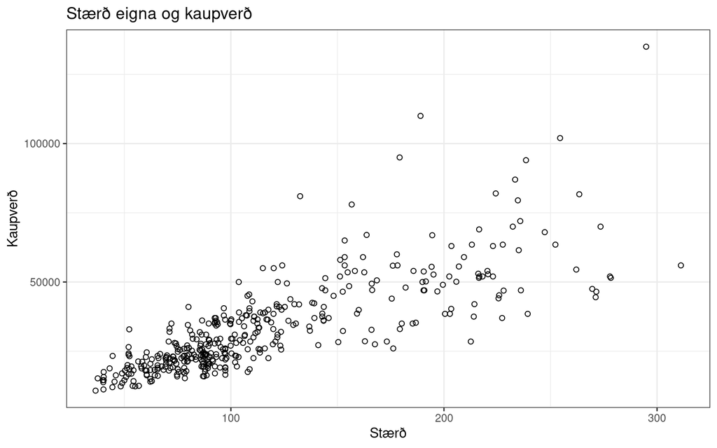

```r
ggplot(urtak, aes(x = birtm2, y = kaupverd)) +
  geom_point(size = 1.6, shape = 1) +
  xlab("Stærð") +
  ylab("Kaupverð") +
  labs(title = "Stærð eigna og kaupverð") +
  theme_bw()
```

## Smíðið einfalt aðhvarfslíkan sem lýsir sambandi stærðar og kaupverðs eigna.

```r
lm1 <- lm(kaupverd ~ birtm2, data = urtak)
summary(lm1)
```

```
##
## Call:
## lm(formula = kaupverd ~ birtm2, data = urtak)
##
## Residuals:
##    Min     1Q Median     3Q    Max
## -27795  -5068  -1016   4507  59322
##
## Coefficients:
##             Estimate Std. Error t value             Pr(>|t|)
## (Intercept) 5693.901   1172.112   4.858           0.00000171 ***
## birtm2       238.010      9.063  26.260 < 0.0000000000000002 ***
## ---
## Signif. codes:  0 '***' 0.001 '**' 0.01 '*' 0.05 '.' 0.1 ' ' 1
##
## Residual standard error: 10230 on 398 degrees of freedom
## Multiple R-squared:  0.6341, Adjusted R-squared:  0.6331
## F-statistic: 689.6 on 1 and 398 DF,  p-value: < 0.00000000000000022
```

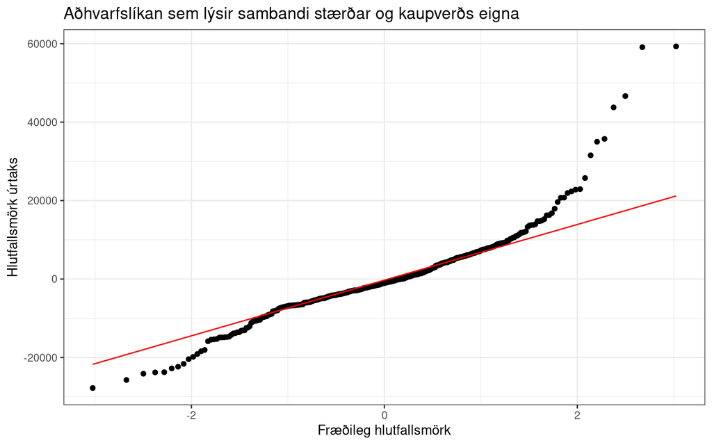

```r
ggplot(
  data = lm1,
  aes(sample = .resid)
) +
  stat_qq() +
  stat_qq_line(color = "red") +
  xlab("Fræðileg hlutfallsmörk") +
  ylab("Hlutfallsmörk úrtaks") +
  labs(title = "Aðhvarfslíkan sem lýsir sambandi stærðar og kaupverðs eigna") +
  theme_bw()
```

Við getum því ályktað út frá hallatölu ($b_1$) að kaupverð hækki um 238.01 þúsund kr. á hvern fermeter.

Skurðpunkturinn ($b_0$) er: 5693.9 og skýringarhlutfallið er ($R^2$): 0.63